# Index Fit Report

North Atlantic Swordfish MSE

Adrian Hordyk adrian@bluematterscience.com

April 28, 2020

# 1 Introduction

This report summarizes the fits across the 288 OMs from the uncertainty grid to the fleet & survey 14 indices from the North Atlantic swordfish.

It also shows plots of the combined index (see SCRS/2017/137) against the predicted total biomass from each of the OMs.

# 2 Indices and Fits

## 2.1 Fleet & Survey Indices

The following plots show the observed index (black solid dots - left panel) and the observed index adjusted for an assumed 1% annual increase in catchability (black solid dots - right panel) for the 14 fleet and survey indices, with the model fits from each OM shown as colored lines (red = no environmental covariate, blue = an environmental covariate).

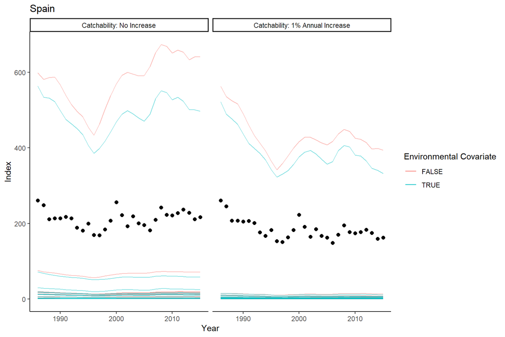

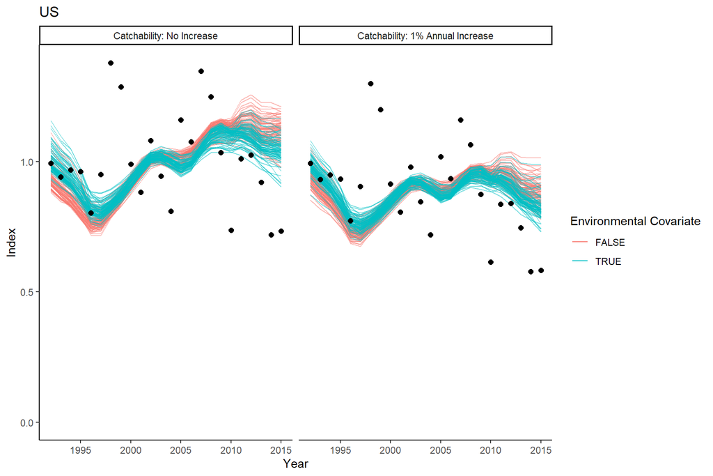

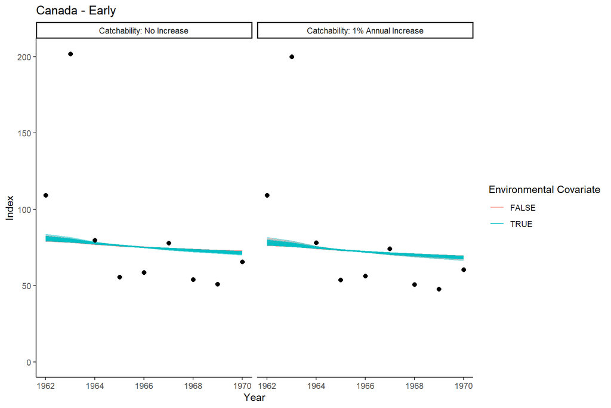

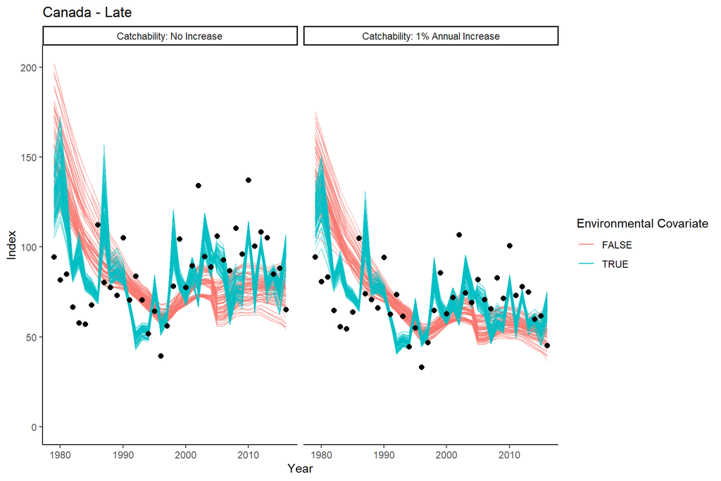

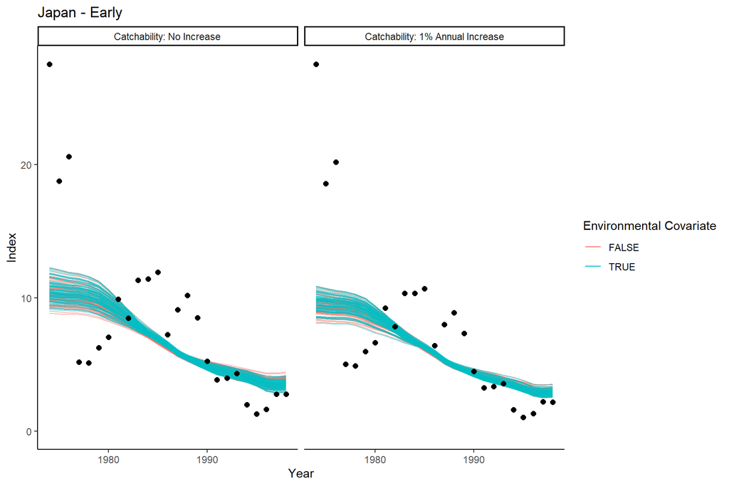

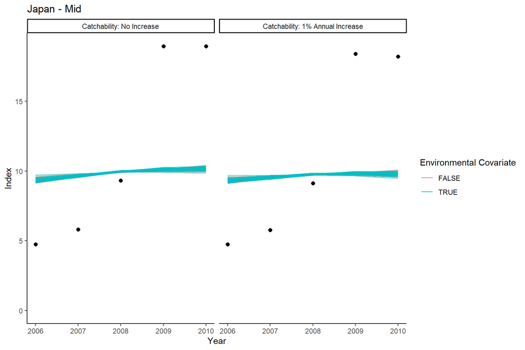

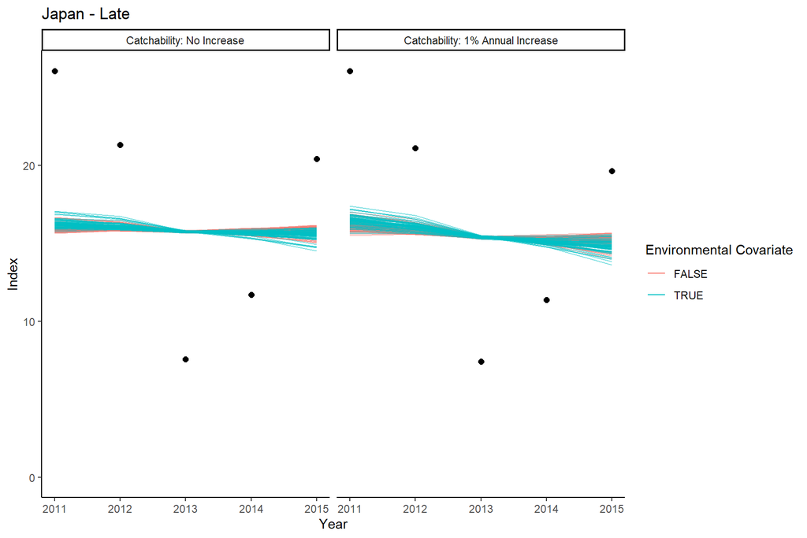

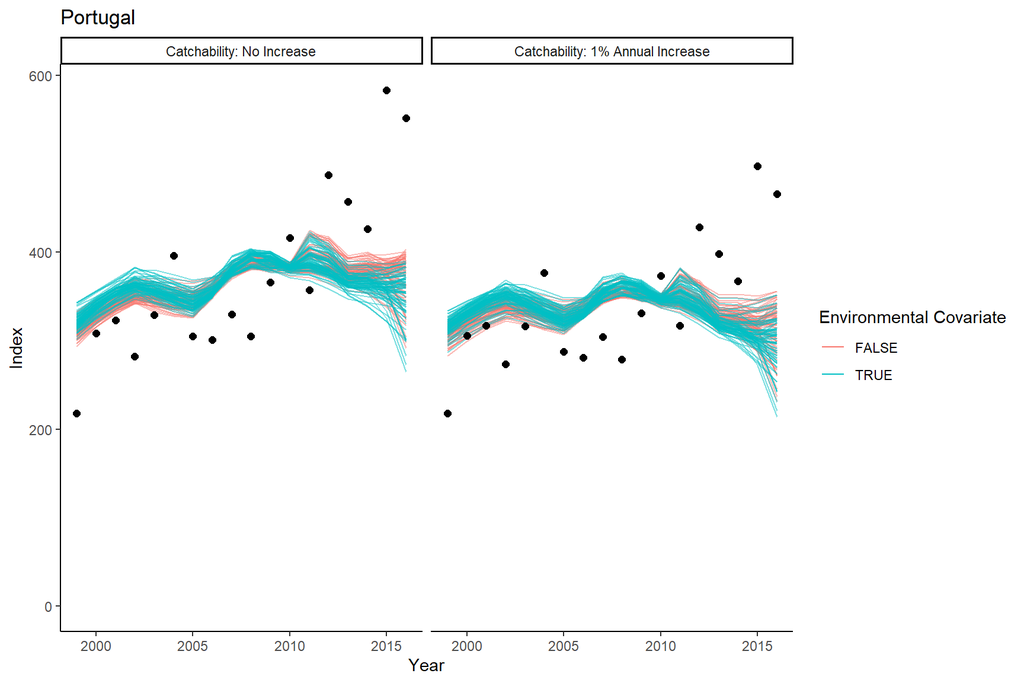

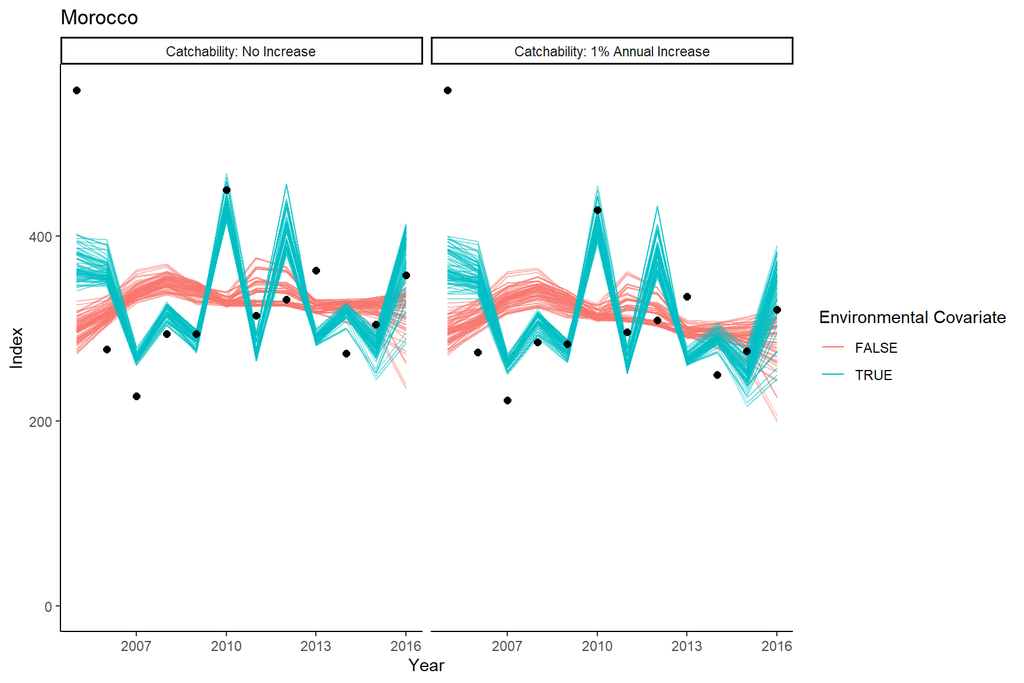

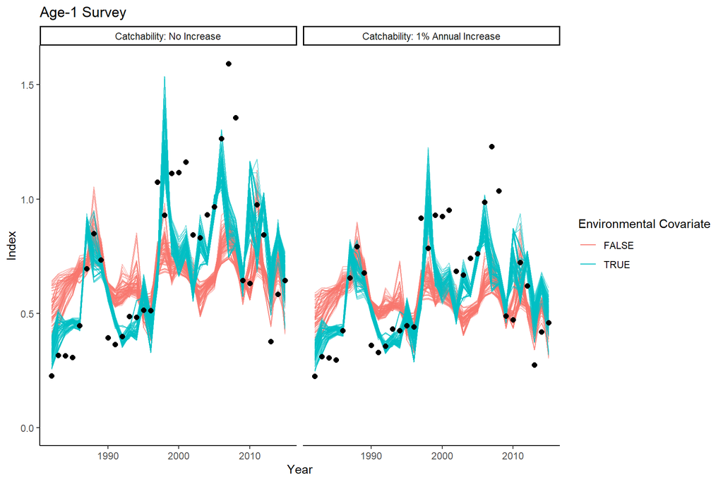

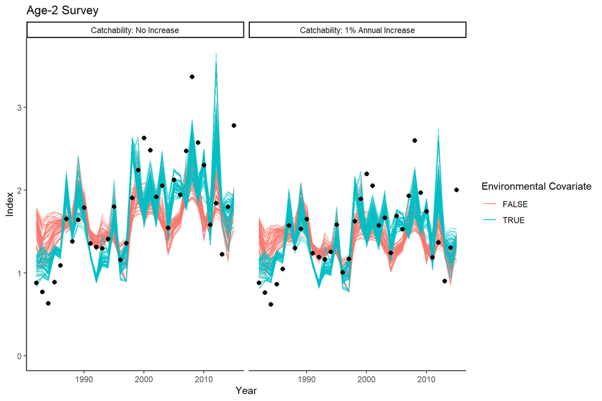

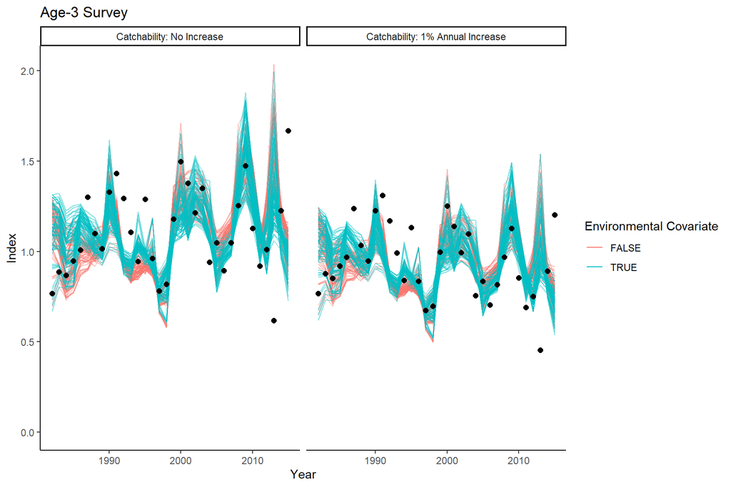

[2 more figures not shown]

## 2.2 Combined Index

The following plot show the combined index (black solid dots) with the standardized predicted total biomass from each OM shown as colored lines (red = no environmental covariate, blue = an environmental covariate). The OMs that were fitted to fleet & survey indices assuming a 1% annual increase in catchability are shown in the right panel.

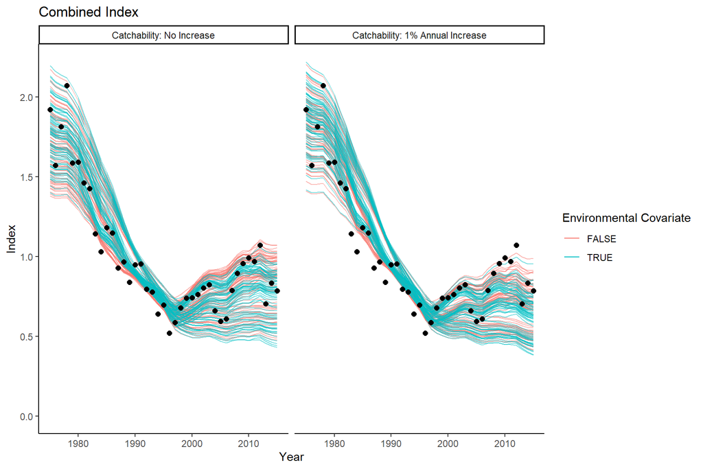

# 3 Summary of Statistical Properties

## 3.1 Fleet & Survey Indices

### 3.1.1 No Increase in Catchability

Histograms of the statistical properties of the log-deviations from the fits to the 14 indices, including auto-correlation (ac), correlation (cor), root-mean-square-error (rmse), and standard deviation (sd), for the 144 OMs using the observed indices.

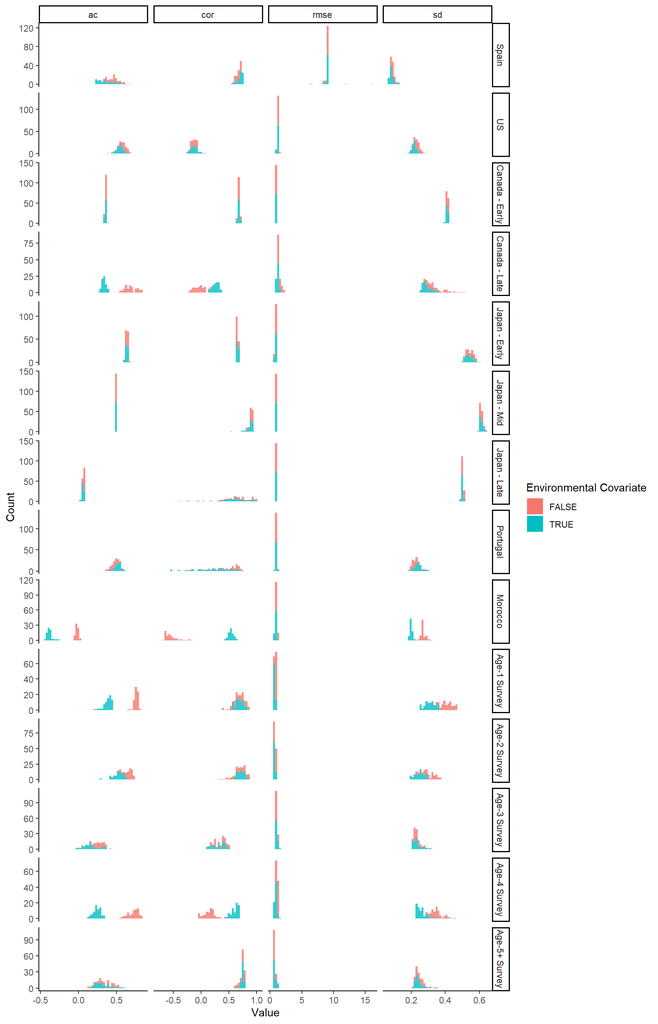

### 3.1.2 1% Annual Increase in Catchability

Histograms of the statistical properties of the log-deviations from the fits to the 14 fleet & survey indices, including auto-correlation (ac), correlation (cor), root-mean-square-error (rmse), and standard deviation (sd), for the 144 OMs using the observed indices adjusted for an assumed 1% annual increase in catchability.

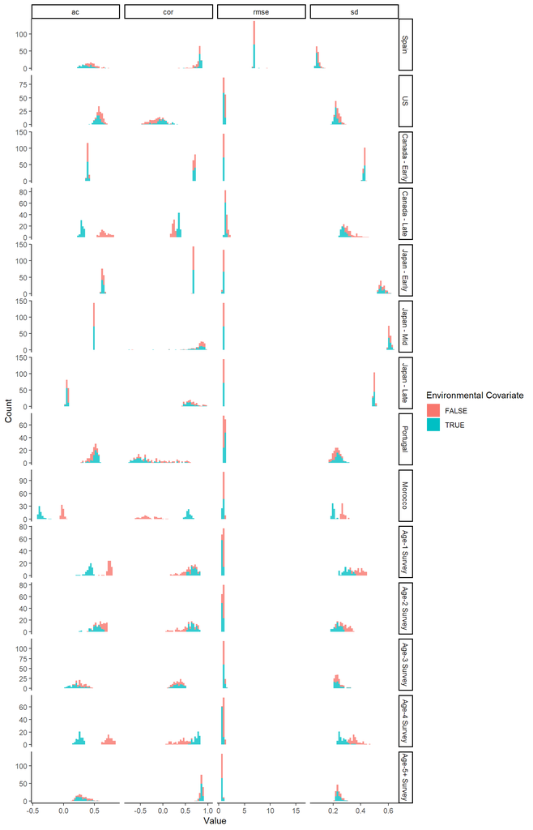

## 3.2 Combined Index

Histograms of the statistical properties of the log-deviations from combined index and the predicted total biomass, including auto-correlation (ac), correlation (cor), root-mean-square-error (rmse), and standard deviation (sd). The bottom row shows the 144 OMs that were fitted to the observed indices that were adjusted for an assumed 1% annual increase in catchability.

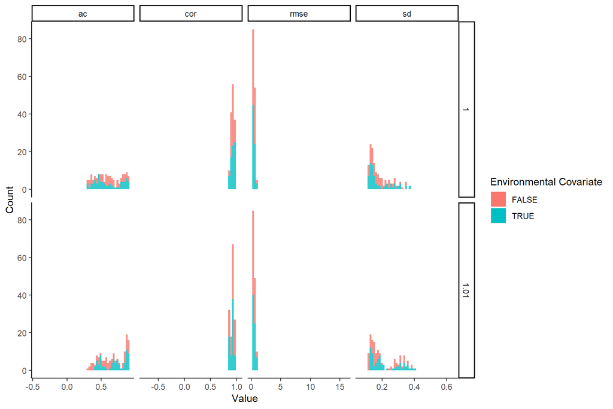